# Statnet Lab 3: Introduction to Inferential Statistics

Zack W Almquist (University of Minnesota)

June 13, 2018

# Necessary R packages

```r
library(sna)
library(network)
library(ergm)
library(networkdata)
```

A note about this tutorial. It is largely based off of Carter Butts Social Network Methodology course at the University of California, Irvine.

# Example data set: Sampson Monistary

Sampson recorded the social interactions among a group of monks while resident as an experimenter on vision, and collected numerous sociometric rankings. During his stay, a political “crisis in the cloister” resulted in the expulsion of four monks (Nos. 2, 3, 17, and 18) and the voluntary departure of several others - most immediately, Nos. 1, 7, 14, 15, and 16. (In the end, only 5, 6, 9, and 11 remained).

Most of the present data are retrospective, collected after the breakup occurred. They concern a period during which a new cohort entered the monastery near the end of the study but before the major conflict began. The exceptions are “liking” data gathered at three times: SAMPLK1 to SAMPLK3 - that reflect changes in group sentiment over time (SAMPLK3 was collected in the same wave as the data described below). Information about the senior monks was not included.

Four relations are coded, with separate matrices for positive and negative ties on the relation. Each member ranked only his top three choices on that tie. The relations are esteem (SAMPES) and disesteem (SAMPDES), liking (SAMPLK) and disliking (SAMPDLK), positive influence (SAMPIN) and negative influence (SAMPNIN), praise (SAMPPR) and blame (SAMPNPR). In all rankings 3 indicates the highest or first choice and 1 the last choice. (Some subjects offered tied ranks for their top four choices).

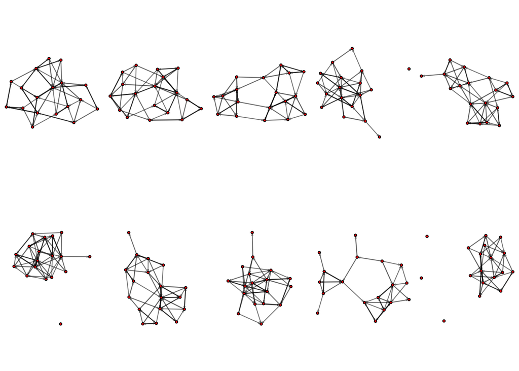

```r
data(sampson)

### Plot the resulting networks
par(mfrow=c(2,5),mar= c(0, 0, 0, 0) + 0.1)
for(i in 1:10){
  plot(sampson[[i]],vertex.cex=1.3,edge.col=rgb(0,0,0,.5),edge.lwd=as.sociomatrix(sampson[[i]],"edgevalue"))
}
```

# More Graph Descriptive Statistics

## The Dyad Census

The dyad census is sometimes call the MAN statistics, because it breaks down into the three key statistics for the network:

- Mutual (M): (i,j) and (j,i)
- Assummetrix(A): (i,j) or (j,i), but not both
- Null(N): neither (i,j) or (j,i)

Some properties of the MAN statistics

$$M+A+N = \textrm{Number of dyads}$$
$$2M+A = \textrm{Number of edges}$$
$$(M+A/2)/(M+A+N) = \textrm{Density}$$

We can do this in R pretty straight forwardedly:

```r
dyad.census(sampson[[1]])
```

```
##      Mut Asym Null
## [1,]  14   27  112
```

## Reciprocity

```r
#-Reciprocity and the dyad census-----------------------------------------------
#
# Get dyadic recprocity for the Sampson monastery data
grecip(sampson)
```

```
##   SAMPLK1   SAMPLK2   SAMPLK3   SAMPDLK    SAMPES   SAMPDES    SAMPIN
## 0.8235294 0.8235294 0.8300654 0.8104575 0.7647059 0.7385621 0.8104575
##   SAMPNIN    SAMPPR    SAMNPR
## 0.7647059 0.8366013 0.8104575
```

```r
# Several relations have identical indices.  The dyad census shows why:
dc<-dyad.census(sampson)                       # Get dyad census
dc                                             # Several have same # Asyms
```

```
##         Mut Asym Null
## SAMPLK1  14   27  112
## SAMPLK2  15   27  111
## SAMPLK3  15   26  112
## SAMPDLK   9   29  115
## SAMPES    9   36  108
## SAMPDES   9   40  104
## SAMPIN   12   29  112
## SAMPNIN   7   36  110
## SAMPPR    7   25  121
## SAMNPR    6   29  118
```

```r
(dc[,1]+dc[,3])/rowSums(dc) == grecip(sampson) # Confirm the definition
```

```
## SAMPLK1 SAMPLK2 SAMPLK3 SAMPDLK  SAMPES SAMPDES  SAMPIN SAMPNIN  SAMPPR
##    TRUE    TRUE    TRUE    TRUE    TRUE    TRUE    TRUE    TRUE    TRUE
##  SAMNPR
##    TRUE
```

```r
# Try edgewise reciprocity (more useful, in general)
grecip(sampson,measure="edgewise")             # Calculate the measure
```

```
##   SAMPLK1   SAMPLK2   SAMPLK3   SAMPDLK    SAMPES   SAMPDES    SAMPIN
## 0.5090909 0.5263158 0.5357143 0.3829787 0.3333333 0.3103448 0.4528302
##   SAMPNIN    SAMPPR    SAMNPR
## 0.2800000 0.3589744 0.2926829
```

```r
2*dc[,1]/(2*dc[,1]+dc[,2])                     # Show it the "hard way"
```

```
##   SAMPLK1   SAMPLK2   SAMPLK3   SAMPDLK    SAMPES   SAMPDES    SAMPIN
## 0.5090909 0.5263158 0.5357143 0.3829787 0.3333333 0.3103448 0.4528302
##   SAMPNIN    SAMPPR    SAMNPR
## 0.2800000 0.3589744 0.2926829
```

```r
# Compare edgewise reciprocity to density ("r4" in the Butts article)
log(grecip(sampson,measure="edgewise")/gden(sampson))
```

```
##   SAMPLK1   SAMPLK2   SAMPLK3   SAMPDLK    SAMPES   SAMPDES    SAMPIN
## 1.0411232 1.0386799 1.0740791 0.9136617 0.6359888 0.4930708 0.9610551
##   SAMPNIN    SAMPPR    SAMNPR
## 0.5385964 1.0355191 0.7813476
```

Are positive relations more reciprocal (relative to density) than negative ones? Let’s try a simple permutation test:

```r
r4<-log(grecip(sampson,measure="edgewise")/gden(sampson))
ispos<-c(TRUE,FALSE,TRUE,FALSE,TRUE,TRUE,TRUE,FALSE,TRUE,FALSE)
obs<-sum(r4[ispos])-sum(r4[!ispos])
reps<-vector()
for(i in 1:1e4){
  temp<-sample(ispos)
  reps[i]<-sum(r4[temp])-sum(r4[!temp])
}
mean(reps>=obs)                                             # Upper tail p-value
```

```
## [1] 0.3626
```

```r
mean(abs(reps)>=abs(obs))                                   # Two-sided version
```

```
## [1] 0.3626
```

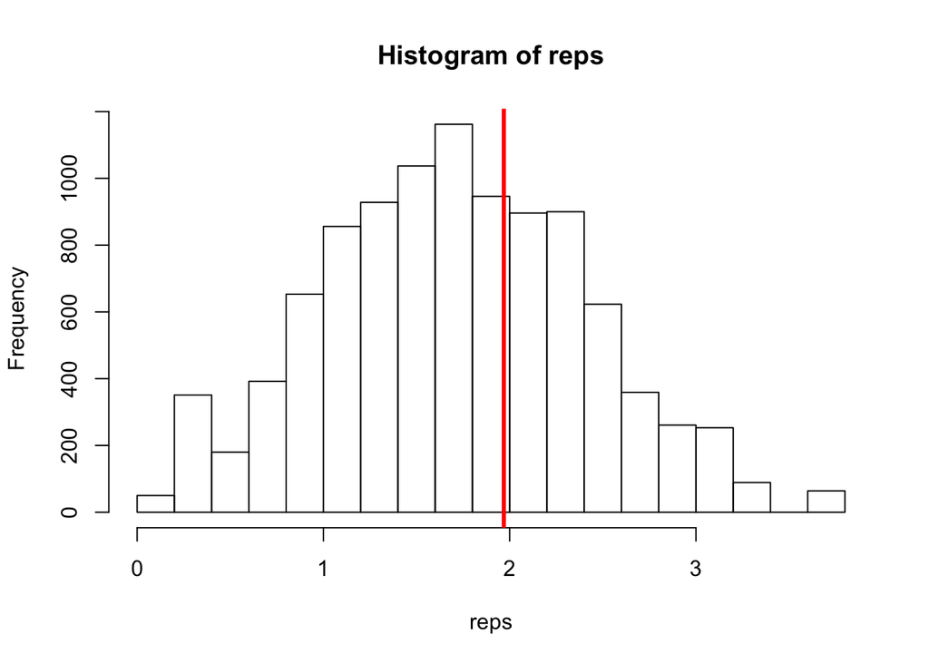

```r
hist(reps)
abline(v=obs,col=2,lwd=3)                                   # Visualize it
```

## Hierarchy and centralization

```r
# Hierarchy is the flip side of reciprocity.  Let's try it here:
hierarchy(sampson)                       # Default measure: 1-dyadic reciprocity
```

```
##  [1] 0.1764706 0.1764706 0.1699346 0.1895425 0.2352941 0.2614379 0.1895425
##  [8] 0.2352941 0.1633987 0.1895425
```

```r
1-grecip(sampson)                        # Manually confirm
```

```
##   SAMPLK1   SAMPLK2   SAMPLK3   SAMPDLK    SAMPES   SAMPDES    SAMPIN
## 0.1764706 0.1764706 0.1699346 0.1895425 0.2352941 0.2614379 0.1895425
##   SAMPNIN    SAMPPR    SAMNPR
## 0.2352941 0.1633987 0.1895425
```

```r
hierarchy(sampson,measure="krackhardt")  # Krackhardt's non-local measure
```

[output not shown]

[output cut: 125 more lines]

[output not shown]

```
##  [1] 0.0000000 0.0000000 0.1111111 0.5769231 0.6143791 0.4135338 0.7605634
##  [8] 0.4765101 0.8125000 0.7021277
```

[output not shown]

[output cut: 125 more lines]

[output not shown]

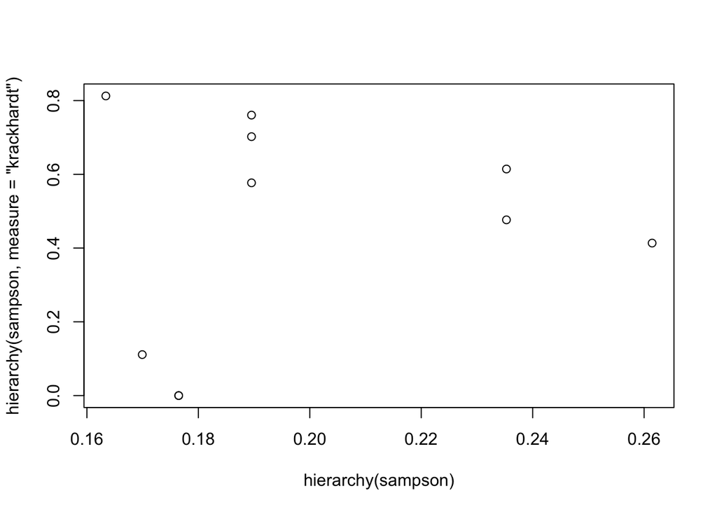

```r
# Visualize the difference:
plot(hierarchy(sampson),hierarchy(sampson,measure="krackhardt"))
```

```r
# What about centralization?
centralization(sampson,degree,cmode="indegree")    #Indegree centralization
```

```
##   SAMPLK1   SAMPLK2   SAMPLK3   SAMPDLK    SAMPES   SAMPDES    SAMPIN
## 0.3702422 0.3010381 0.1799308 0.3356401 0.2491349 0.3598616 0.5017301
##   SAMPNIN    SAMPPR    SAMNPR
## 0.3252595 0.1764706 0.3564014
```

```r
centralization(sampson,degree,cmode="outdegree")   #Outdegree centralization
```

```
##    SAMPLK1    SAMPLK2    SAMPLK3    SAMPDLK     SAMPES    SAMPDES
## 0.05882353 0.05190311 0.05536332 0.08650519 0.06228374 0.11072664
##     SAMPIN    SAMPNIN     SAMPPR     SAMNPR
## 0.06574394 0.13840830 0.11418685 0.16955017
```

```r
centralization(sampson,betweenness)                #Betweenness centralization
```

```
##    SAMPLK1    SAMPLK2    SAMPLK3    SAMPDLK     SAMPES    SAMPDES
## 0.25454770 0.30175173 0.25810986 0.11366473 0.12262111 0.12432958
##     SAMPIN    SAMPNIN     SAMPPR     SAMNPR
## 0.11937716 0.17799426 0.13754325 0.09926471
```

## Transitivity

```r
# Get transitivity for the Sampson monastery data
gtrans(sampson)
```

```
##  [1] 0.1678322 0.2941176 0.3475177 0.1209677 0.3402778 0.2514286 0.3984962
##  [8] 0.1190476 0.3625000 0.2031250
```

```r
# How does transitivity compare to density?  (Log-odds method)
log(gtrans(sampson)/gden(sampson))
```

```
##     SAMPLK1     SAMPLK2     SAMPLK3     SAMPDLK      SAMPES     SAMPDES
## -0.06853888  0.45675840  0.64129382 -0.23879386  0.65660805  0.28254575
##      SAMPIN     SAMPNIN      SAMPPR      SAMNPR
##  0.83323597 -0.31666961  1.04529265  0.41607931
```

```r
# Are positive relations more transitive (relative to density) than negative
# ones?  (Compare to last lecture's reciprocity test.)  Let's try a vector
# permutation test:
ltr<-log(gtrans(sampson)/gden(sampson))
ispos<-c(TRUE,FALSE,TRUE,FALSE,TRUE,TRUE,TRUE,FALSE,TRUE,FALSE)
obs<-sum(ltr[ispos])-sum(ltr[!ispos])
reps<-vector()
for(i in 1:1e4){
  temp<-sample(ispos)
  reps[i]<-sum(ltr[temp])-sum(ltr[!temp])
}
mean(reps>=obs)                                             # Upper tail p-value
```

```
## [1] 0.0509
```

```r
mean(abs(reps)>=abs(obs))                                   # Two-sided version
```

```
## [1] 0.0509
```

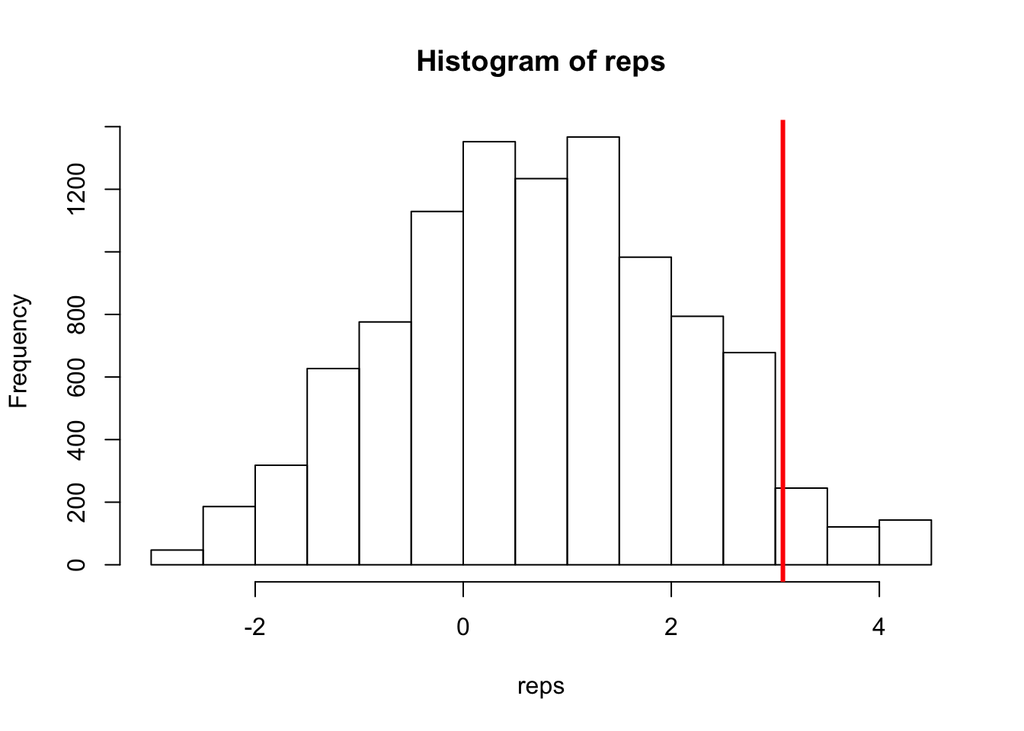

```r
hist(reps)
abline(v=obs,col=2,lwd=3)                                   # Visualize it
```

```r
# Now, let's get the triad census for each network
triad.census(sampson)
```

```
##         003 012 102 021D 021U 021C 111D 111U 030T 030C 201 120D 120U 120C
## SAMPLK1 327 206 132    4   36   28   33   21    7    0  13    2    0    4
## SAMPLK2 302 236 140    8   25   20   40   15    2    2  10    5    3    0
## SAMPLK3 293 257 155    7   13   20   27   13    3    1   9    7    1    3
## SAMPDLK 364 244  65   15   29   25   39   12    4    1  10    1    2    5
## SAMPES  277 293  98    9   26   54   16    9   14    3   1    2   10    2
## SAMPDES 280 261  58   30   53   43   44   11   13    2   5    4    1    6
## SAMPIN  321 244 114    9   37   19   35   11    5    0   2    7    2    3
## SAMPNIN 313 281  51   25   39   43   32   13    7    2   5    1    0    3
## SAMPPR  395 270  78    6   10   20    9   10    7    0   0    1    2    4
## SAMNPR  395 238  55   24   52    9   19    8    8    0   5    0    0    2
##         210 300
## SAMPLK1   3   0
## SAMPLK2   7   1
## SAMPLK3   5   2
## SAMPDLK   0   0
## SAMPES    1   1
## SAMPDES   5   0
## SAMPIN    5   2
## SAMPNIN   1   0
## SAMPPR    4   0
## SAMNPR    1   0
```

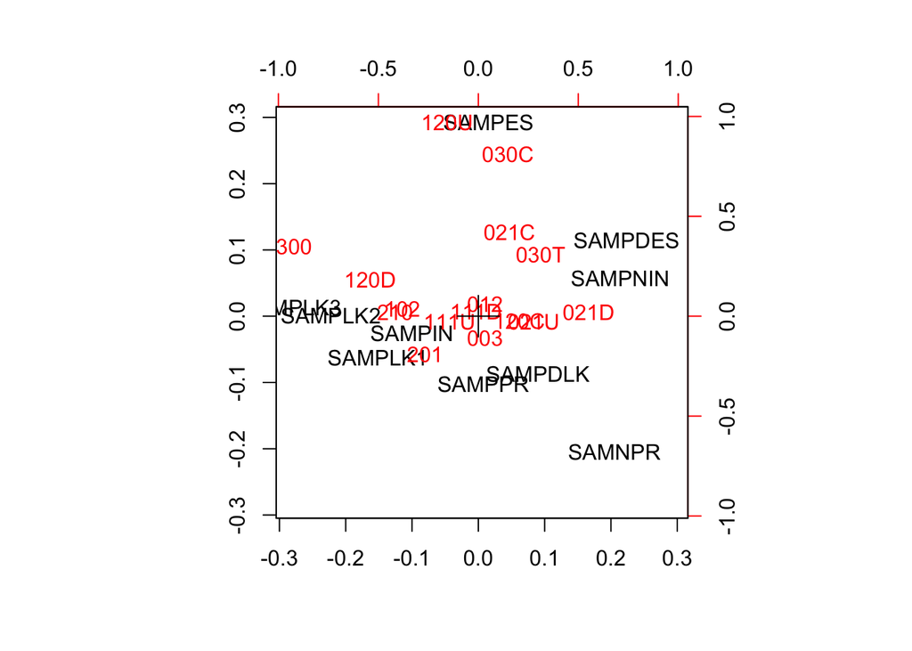

```r
# Cool trick: two-way correspondence analysis of graphs and their triad census
# scores (aka a "Faust diagram").  Networks here appear close to the triad
# types they contain at excess frequency (distances are chi-squared based;
# see references in ?corresp for more detail).
library(MASS)                                        # Requires the MASS package
plot(corresp(triad.census(sampson),nf=2))       # Plot network/triad association
```

```r
# What if this data were symmetric?  We can symmetrize to illustrate.
triad.census(symmetrize(sampson),mode="graph")    #Need to use mode="graph" here
```

```
##         0   1   2  3
##  [1,] 327 338 135 16
##  [2,] 302 376 118 20
##  [3,] 293 412  89 22
##  [4,] 364 309 130 13
##  [5,] 277 391 115 33
##  [6,] 280 319 186 31
##  [7,] 321 358 113 24
##  [8,] 313 332 157 14
##  [9,] 395 348  55 18
## [10,] 395 293 117 11
```

### A bit about the triad census

A visualization of the Triad Census:

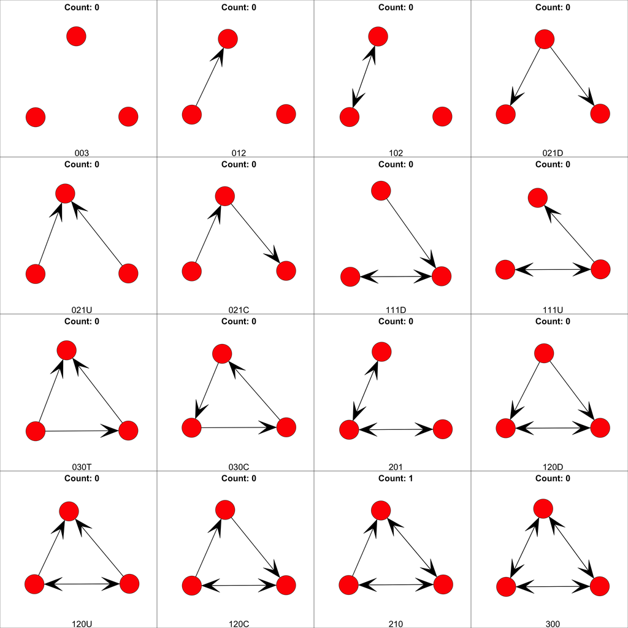

Compute the observed triad census for all the sampson networks:

```r
trCensus<-triad.census(sampson)
trCensus
```

```
##         003 012 102 021D 021U 021C 111D 111U 030T 030C 201 120D 120U 120C
## SAMPLK1 327 206 132    4   36   28   33   21    7    0  13    2    0    4
## SAMPLK2 302 236 140    8   25   20   40   15    2    2  10    5    3    0
## SAMPLK3 293 257 155    7   13   20   27   13    3    1   9    7    1    3
## SAMPDLK 364 244  65   15   29   25   39   12    4    1  10    1    2    5
## SAMPES  277 293  98    9   26   54   16    9   14    3   1    2   10    2
## SAMPDES 280 261  58   30   53   43   44   11   13    2   5    4    1    6
## SAMPIN  321 244 114    9   37   19   35   11    5    0   2    7    2    3
## SAMPNIN 313 281  51   25   39   43   32   13    7    2   5    1    0    3
## SAMPPR  395 270  78    6   10   20    9   10    7    0   0    1    2    4
## SAMNPR  395 238  55   24   52    9   19    8    8    0   5    0    0    2
##         210 300
## SAMPLK1   3   0
## SAMPLK2   7   1
## SAMPLK3   5   2
## SAMPDLK   0   0
## SAMPES    1   1
## SAMPDES   5   0
## SAMPIN    5   2
## SAMPNIN   1   0
## SAMPPR    4   0
## SAMNPR    1   0
```

## Centrality Scores

```r
data(emon)                                     #Load Drabek et al. data

#Extract ties from the Cheyenne EMON communicating at least "every few hours"
g<-as.sociomatrix(emon[[1]],"Frequency")       #Need to get the frequency info
g<-symmetrize((g>0)&(g<4))                     #Note the reverse coding!

#Get some potential covariates
drs<-emon[[1]]%v%"Decision.Rank.Score"         #Get decision rank (see man page)
crs<-emon[[1]]%v%"Command.Rank.Score"          #Get command rank

#Calculate some basic centrality measures
deg<-degree(g,gmode="graph")
bet<-betweenness(g,gmode="graph")
clo<-closeness(g,gmode="graph")

#Raw correlations
cor(cbind(deg,bet,clo),cbind(drs,crs))
```

```
##           drs       crs
## deg 0.7070788 0.6354761
## bet 0.8599111 0.6879251
## clo 0.7918351 0.6978672
```

```r
#Classical tests (using asymptotic t distribution)
cor.test(deg,drs)
```

```
##
##  Pearson's product-moment correlation
##
## data:  deg and drs
## t = 3.4638, df = 12, p-value = 0.004684
## alternative hypothesis: true correlation is not equal to 0
## 95 percent confidence interval:
##  0.2824719 0.9000094
## sample estimates:
##       cor
## 0.7070788
```

```r
cor.test(bet,drs)
```

```
##
##  Pearson's product-moment correlation
##
## data:  bet and drs
## t = 5.8357, df = 12, p-value = 8.014e-05
## alternative hypothesis: true correlation is not equal to 0
## 95 percent confidence interval:
##  0.6056688 0.9548426
## sample estimates:
##       cor
## 0.8599111
```

```r
cor.test(clo,drs)
```

```
##
##  Pearson's product-moment correlation
##
## data:  clo and drs
## t = 4.4913, df = 12, p-value = 0.0007377
## alternative hypothesis: true correlation is not equal to 0
## 95 percent confidence interval:
##  0.4505429 0.9311917
## sample estimates:
##       cor
## 0.7918351
```

```r
#Permutation tests
perm.cor.test<-function(x,y,niter=5000){  #Define a simple test function
  c.obs<-cor(x,y,use="complete.obs")
  c.rep<-vector()
  for(i in 1:niter)
    c.rep[i]<-cor(x,sample(y),use="complete.obs")
  cat("Vector Permutation Test:\n\tObserved correlation: ",c.obs,"\tReplicate quantiles (niter=",niter,")\n",sep="")
  cat("\t\tPr(rho>=obs):",mean(c.rep>=c.obs),"\n")
  cat("\t\tPr(rho<=obs):",mean(c.rep<=c.obs),"\n")
  cat("\t\tPr(|rho|>=|obs|):",mean(abs(c.rep)>=abs(c.obs)),"\n")
  invisible(list(obs=c.obs,rep=c.rep))
}
perm.cor.test(deg,drs)                     #Non-parametric tests of correlation
```

```
## Vector Permutation Test:
##  Observed correlation: 0.7070788 Replicate quantiles (niter=5000)
##      Pr(rho>=obs): 0
##      Pr(rho<=obs): 1
##      Pr(|rho|>=|obs|): 0.002
```

```r
perm.cor.test(bet,drs)
```

```
## Vector Permutation Test:
##  Observed correlation: 0.8599111 Replicate quantiles (niter=5000)
##      Pr(rho>=obs): 0.005
##      Pr(rho<=obs): 0.995
##      Pr(|rho|>=|obs|): 0.005
```

```r
perm.cor.test(clo,drs)
```

```
## Vector Permutation Test:
##  Observed correlation: 0.7918351 Replicate quantiles (niter=5000)
##      Pr(rho>=obs): 0
##      Pr(rho<=obs): 1
##      Pr(|rho|>=|obs|): 0
```

## Mixing Matrix

```r
data("fauxhigh")
```

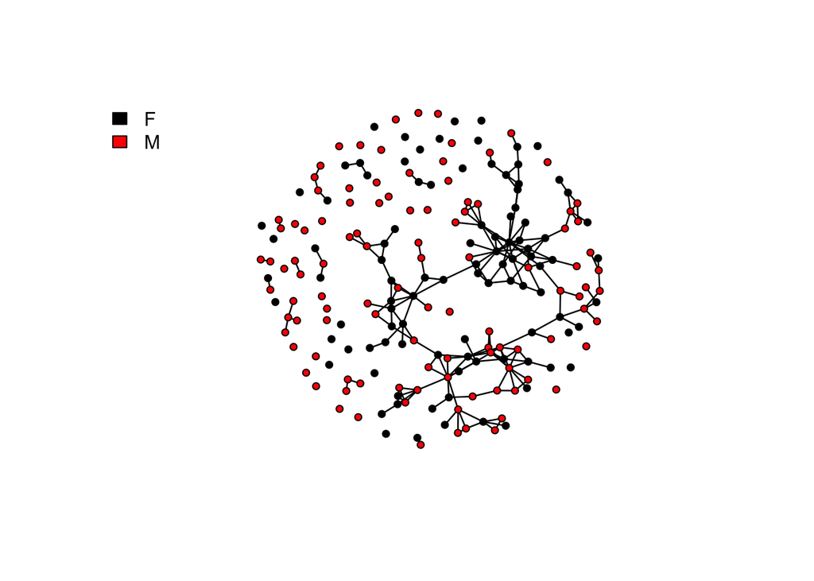

```r
data("faux.mesa.high")
fauxhigh<-faux.mesa.high

# Display the data, along with covariates
plot(fauxhigh,vertex.col="Sex")        # Plot by gender (covariate is misnamed!)
vals<-sort(unique(fauxhigh%v%"Sex"))   # Let's add a legend....
legend("topleft",fill=1:length(vals),legend=vals,bty="n")
```

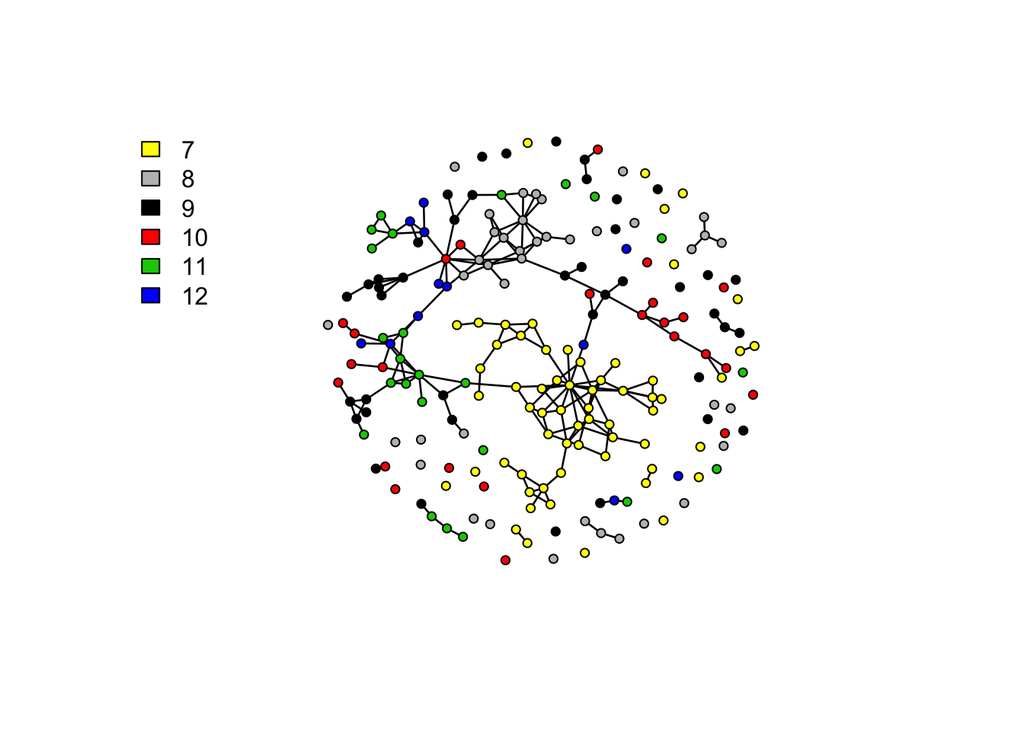

```r
plot(fauxhigh,vertex.col="Grade")      # Now, plot by grade
legend("topleft",fill=7:12,legend=7:12,bty="n")
```

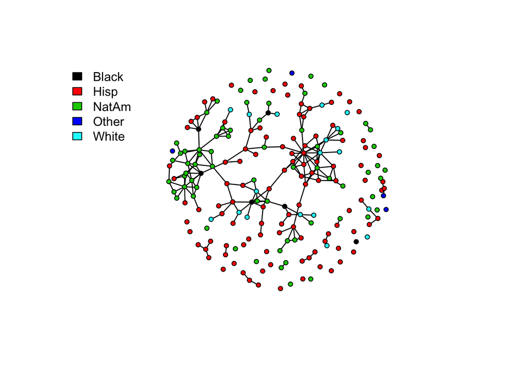

```r
plot(fauxhigh,vertex.col="Race")       # Finally, plot by race
vals<-sort(unique(fauxhigh%v%"Race"))
legend("topleft",fill=1:length(vals),legend=vals,bty="n")
```

```r
#-Obtaining mixing matrices-----------------------------------------------------

# The mixingmatrix command is poorly documented, but very useful.  Let's
# obtain mixing matrices for each of the above attributes:
mms<-mixingmatrix(fauxhigh,"Sex")               # Compute w/a network object and
mmg<-mixingmatrix(fauxhigh,"Grade")             # attribute name
mmr<-mixingmatrix(fauxhigh,"Race")
mms                                             # See what we have...
```

```
## Note:  Marginal totals can be misleading
##  for undirected mixing matrices.
##    F  M
## F 82 71
## M 71 50
```

```r
mmg
```

```
## Note:  Marginal totals can be misleading
##  for undirected mixing matrices.
##     7  8  9 10 11 12
## 7  75  0  0  1  1  1
## 8   0 33  2  4  2  1
## 9   0  2 23  7  6  4
## 10  1  4  7  9  1  5
## 11  1  2  6  1 17  5
## 12  1  1  4  5  5  6
```

```r
mmr
```

```
## Note:  Marginal totals can be misleading
##  for undirected mixing matrices.
##       Black Hisp NatAm Other White
## Black     0    8    13     0     5
## Hisp      8   53    41     1    22
## NatAm    13   41    46     0    10
## Other     0    1     0     0     0
## White     5   22    10     0     4
```

```r
names(mms)                                      # This is a complex object
```

```
## [1] "type"   "matrix"
```

```r
class(mms)
```

```
## [1] "mixingmatrix"
```

```r
mms$matrix                                      # Extract the mixing matrix
```

```
##     To
## From  F  M
##    F 82 71
##    M 71 50
```

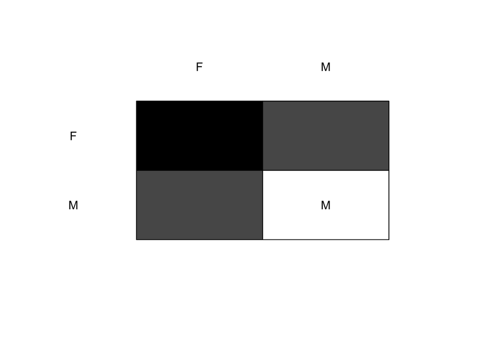

```r
# Can crudely visualize using plot.sociomatrix:
plot.sociomatrix(mms$matrix)                    # Must use matrix, not object
```

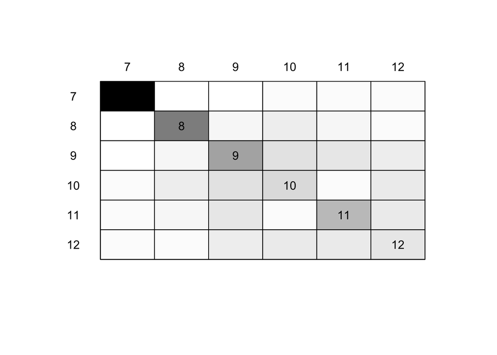

```r
plot.sociomatrix(mmg$matrix)
```

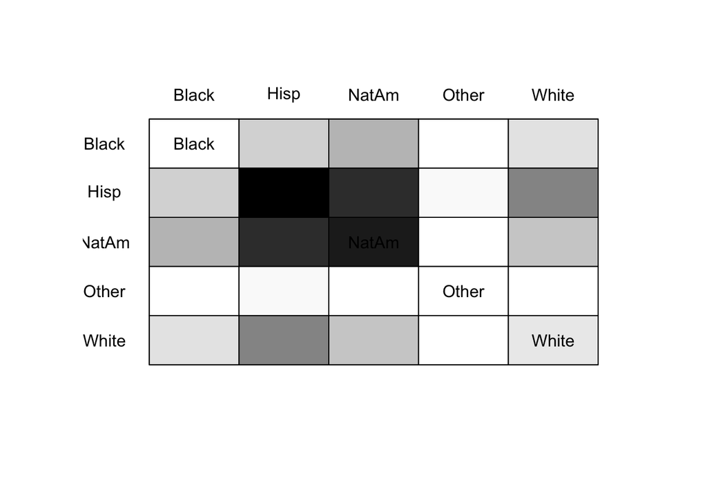

```r
plot.sociomatrix(mmr$matrix)
```

```r
#
#-Obtaining expectations and z-scores-------------------------------------------
#
# Let's examine mixing by grade....
mmg
```

```
## Note:  Marginal totals can be misleading
##  for undirected mixing matrices.
##     7  8  9 10 11 12
## 7  75  0  0  1  1  1
## 8   0 33  2  4  2  1
## 9   0  2 23  7  6  4
## 10  1  4  7  9  1  5
## 11  1  2  6  1 17  5
## 12  1  1  4  5  5  6
```

```r
gmarg<-rowSums(mmg$matrix)                       # Marginals for grade
gmarg
```

```
##  7  8  9 10 11 12
## 78 42 42 27 32 22
```

```r
emmg<-(gmarg%o%gmarg)/sum(gmarg)                 # Expected mixing matrix
emmg
```

```
##            7         8         9       10        11       12
## 7  25.037037 13.481481 13.481481 8.666667 10.271605 7.061728
## 8  13.481481  7.259259  7.259259 4.666667  5.530864 3.802469
## 9  13.481481  7.259259  7.259259 4.666667  5.530864 3.802469
## 10  8.666667  4.666667  4.666667 3.000000  3.555556 2.444444
## 11 10.271605  5.530864  5.530864 3.555556  4.213992 2.897119
## 12  7.061728  3.802469  3.802469 2.444444  2.897119 1.991770
```

```r
sum(emmg)==sum(gmarg)                 # Confirm: edges preserved
```

```
## [1] TRUE
```

```r
sum(gmarg)==sum(mmg$matrix)           # Confirm: edges preserved
```

```
## [1] TRUE
```

```r
dmmg<-mmg$matrix-emmg                            # Divergence from expectation
dmmg
```

```
##     To
## From           7           8           9          10          11
##   7   49.9629630 -13.4814815 -13.4814815  -7.6666667  -9.2716049
##   8  -13.4814815  25.7407407  -5.2592593  -0.6666667  -3.5308642
##   9  -13.4814815  -5.2592593  15.7407407   2.3333333   0.4691358
##   10  -7.6666667  -0.6666667   2.3333333   6.0000000  -2.5555556
##   11  -9.2716049  -3.5308642   0.4691358  -2.5555556  12.7860082
##   12  -6.0617284  -2.8024691   0.1975309   2.5555556   2.1028807
##     To
## From          12
##   7   -6.0617284
##   8   -2.8024691
##   9    0.1975309
##   10   2.5555556
##   11   2.1028807
##   12   4.0082305
```

```r
zmmg<-dmmg/sqrt(emmg)                            # Approximate z-scores
zmmg                                             # Note the strong homophily!
```

```
##     To
## From          7          8          9         10         11         12
##   7   9.9851989 -3.6717137 -3.6717137 -2.6042372 -2.8929156 -2.2810824
##   8  -3.6717137  9.5537723 -1.9519938 -0.3086067 -1.5013589 -1.4371695
##   9  -3.6717137 -1.9519938  5.8422349  1.0801234  0.1994812  0.1012983
##   10 -2.6042372 -0.3086067  1.0801234  3.4641016 -1.3552880  1.6345388
##   11 -2.8929156 -1.5013589  0.1994812 -1.3552880  6.2285670  1.2354678
##   12 -2.2810824 -1.4371695  0.1012983  1.6345388  1.2354678  2.8400968
```

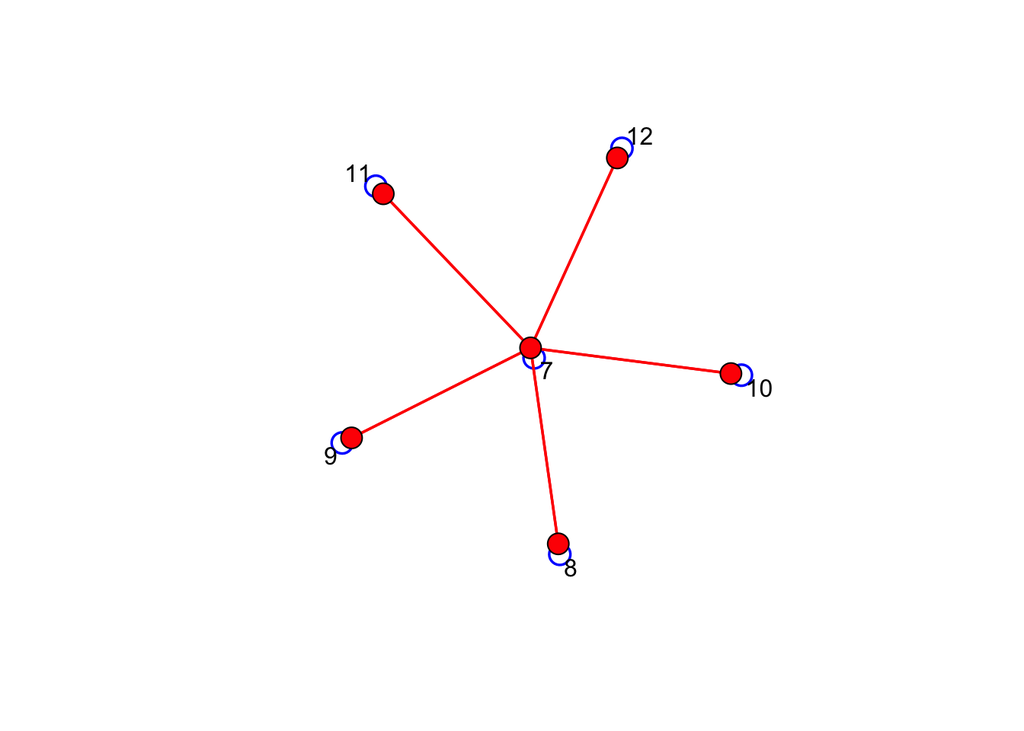

```r
#Plot the z-scores as a reduced form signed blockmodel
gplot(abs(zmmg)>2,edge.col=sign(zmmg)+3,label=7:12,boxed.lab=FALSE,
    usearrows=FALSE,diag=TRUE)                   # All avoid grade 7?
```

## Regression and Node Level Indices

```r
#Using NLIs as regression covariates--------------------------------------------
data(emon)

pstaff<-emon[[1]]%v%"Paid.Staff"                     # Get more EMON covariates
vstaff<-emon[[1]]%v%"Volunteer.Staff"
govt<-((emon[[1]]%v%"Sponsorship")!="Private")

#Very simple model: decision rank is linear in size, degree, and govt status
mod<-lm(drs~deg+pstaff+vstaff+govt)
summary(mod)
```

```
##
## Call:
## lm(formula = drs ~ deg + pstaff + vstaff + govt)
##
## Residuals:
##      Min       1Q   Median       3Q      Max
## -10.7782  -3.7590  -0.0674   3.3244  11.3870
##
## Coefficients:
##               Estimate Std. Error t value Pr(>|t|)
## (Intercept) -13.540134   6.572375  -2.060   0.0783 .
## deg           3.568322   1.068874   3.338   0.0124 *
## pstaff       -0.136112   0.047249  -2.881   0.0236 *
## vstaff        0.021232   0.009218   2.303   0.0547 .
## govtTRUE      4.594572   8.345941   0.551   0.5991
## ---
## Signif. codes:  0 '***' 0.001 '**' 0.01 '*' 0.05 '.' 0.1 ' ' 1
##
## Residual standard error: 8.609 on 7 degrees of freedom
##   (2 observations deleted due to missingness)
## Multiple R-squared:  0.7767, Adjusted R-squared:  0.649
## F-statistic: 6.085 on 4 and 7 DF,  p-value: 0.01958
```

```r
anova(mod)                                            #Some useful lm tools
```

```
## Analysis of Variance Table
##
## Response: drs
##           Df  Sum Sq Mean Sq F value   Pr(>F)
## deg        1 1172.37 1172.37 15.8182 0.005343 **
## pstaff     1  233.54  233.54  3.1510 0.119144
## vstaff     1  375.74  375.74  5.0696 0.059060 .
## govt       1   22.46   22.46  0.3031 0.599086
## Residuals  7  518.81   74.12
## ---
## Signif. codes:  0 '***' 0.001 '**' 0.01 '*' 0.05 '.' 0.1 ' ' 1
```

```r
AIC(mod)
```

```
## [1] 91.25404
```

```r
#Does total size change the picture?
mod2<-lm(drs~deg+I(pstaff+vstaff)+govt)                #Pre-add sizes
summary(mod2)
```

```
##
## Call:
## lm(formula = drs ~ deg + I(pstaff + vstaff) + govt)
##
## Residuals:
##     Min      1Q  Median      3Q     Max
## -18.186  -5.030   1.503   3.858  22.006
##
## Coefficients:
##                      Estimate Std. Error t value Pr(>|t|)
## (Intercept)        -12.014008   8.989106  -1.337   0.2181
## deg                  3.194941   1.455684   2.195   0.0595 .
## I(pstaff + vstaff)  -0.002397   0.005447  -0.440   0.6715
## govtTRUE            -1.270232  11.097043  -0.114   0.9117
## ---
## Signif. codes:  0 '***' 0.001 '**' 0.01 '*' 0.05 '.' 0.1 ' ' 1
##
## Residual standard error: 11.81 on 8 degrees of freedom
##   (2 observations deleted due to missingness)
## Multiple R-squared:  0.5193, Adjusted R-squared:  0.3391
## F-statistic: 2.881 on 3 and 8 DF,  p-value: 0.1029
```

```r
#Try with alternative measures....
mod3<-lm(drs~bet+pstaff+vstaff+govt)                   #Betweenness
summary(mod3)
```

```
##
## Call:
## lm(formula = drs ~ bet + pstaff + vstaff + govt)
##
## Residuals:
##      Min       1Q   Median       3Q      Max
## -10.7723  -2.4300  -0.2022   1.2789  13.6188
##
## Coefficients:
##              Estimate Std. Error t value Pr(>|t|)
## (Intercept)  0.135492   4.587574   0.030  0.97726
## bet          2.227938   0.588046   3.789  0.00681 **
## pstaff      -0.057633   0.046155  -1.249  0.25192
## vstaff       0.009056   0.008591   1.054  0.32686
## govtTRUE    10.056924   6.769510   1.486  0.18096
## ---
## Signif. codes:  0 '***' 0.001 '**' 0.01 '*' 0.05 '.' 0.1 ' ' 1
##
## Residual standard error: 7.936 on 7 degrees of freedom
##   (2 observations deleted due to missingness)
## Multiple R-squared:  0.8102, Adjusted R-squared:  0.7018
## F-statistic: 7.471 on 4 and 7 DF,  p-value: 0.01142
```

```r
mod4<-lm(drs~clo+pstaff+vstaff+govt)                   #Closeness
summary(mod4)
```

```
##
## Call:
## lm(formula = drs ~ clo + pstaff + vstaff + govt)
##
## Residuals:
##      Min       1Q   Median       3Q      Max
## -11.4276  -2.5785  -0.7013   2.3565  11.4079
##
## Coefficients:
##               Estimate Std. Error t value Pr(>|t|)
## (Intercept) -53.609770  13.809378  -3.882  0.00604 **
## clo          90.970954  21.935402   4.147  0.00431 **
## pstaff       -0.118669   0.040655  -2.919  0.02237 *
## vstaff        0.019130   0.007906   2.420  0.04612 *
## govtTRUE      4.502737   7.041575   0.639  0.54288
## ---
## Signif. codes:  0 '***' 0.001 '**' 0.01 '*' 0.05 '.' 0.1 ' ' 1
##
## Residual standard error: 7.455 on 7 degrees of freedom
##   (2 observations deleted due to missingness)
## Multiple R-squared:  0.8325, Adjusted R-squared:  0.7368
## F-statistic:   8.7 on 4 and 7 DF,  p-value: 0.007522
```

```r
AIC(mod,mod3,mod4)                                     #Closeness wins!
```

```
##      df      AIC
## mod   6 91.25404
## mod3  6 89.29962
## mod4  6 87.79874
```

# Introduction to Random Graphs

A graph $G=(V,E)$ can be considered a random variable $G$ on some set of $G$ possible graphs. The proability mass function (pmf) can thus be written as $\Pr(G=g)$.

In practice, we primarly work the adjaceny matrix represenation. We can consider $Y$ to be the matrix of random graph $G$. Then $Y$ is a random matrix with pmf $\Pr(Y=y)$.

Then $Y_{ij}$ is a binary random variable which indicates the state of the (random) $i,j$ edge. Then we can write the marginal of $Y_{ij}$ edge stat as $\Pr(Y_{ij}=$y_{ij})$.

## Erdos-Renyi Random graph

The Erdos-Renyi Random graph is based on the notion of conditioning on the size and density of the network. This is sometimes call the NM family of random graphs.

- N is the network size
- M is the number of (observed) edges
- $M_m$ is the maxim number of edges in the graph

Then

$$\Pr(G=g|N,M) = \frac{1}{{\choose M_m M}}$$

In r,

```r
rgnm(1, 10, 20)
```

```
##       [,1] [,2] [,3] [,4] [,5] [,6] [,7] [,8] [,9] [,10]
##  [1,]    0    0    0    0    0    1    0    0    1     1
##  [2,]    0    0    0    0    0    0    0    0    0     0
##  [3,]    0    0    0    1    0    0    0    0    0     0
##  [4,]    0    0    0    0    0    1    0    0    0     1
##  [5,]    1    0    0    0    0    1    0    0    0     0
##  [6,]    0    0    0    1    1    0    0    0    0     1
##  [7,]    1    0    0    1    1    0    0    0    1     0
##  [8,]    1    0    0    0    0    1    0    0    0     0
##  [9,]    0    1    0    0    1    0    0    0    0     0
## [10,]    0    0    0    0    0    0    0    0    1     0
```

## Brnoulli Graphs

Bernoulli graphs come from the “idea” that we if all ties are independent (or conditionally independent) we can represent the graph as series of bernoullie trials. This is sometimes called the NP family of network models. If we use the above notation:

$$\Pr(G=g|N,p) = p^M(1-p)^{M_m-M}$$

Notice that in matrix notation this will be:

**Directed Case**
$$\Pr(Y=y|N,p) = \prod_{i\neq j} p^{Y_{ij}}(1-p)^{1-Y_{ij}}$$
**Undirected Case**
$$\Pr(Y=y|N,p) = \prod_{i< j} p^{Y_{ij}}(1-p)^{1-Y_{ij}}$$
The matrix notation is very important because it naturally leads to first class of (inferential) network models. Notice that we could fit $\Pr(Y=y|N,p)$ with standard likelihood methods - further, if we are willing to assume that $logit(p)$ is linear in the predictors we will have logistic regression!

We can generate Bernoulli Random Graphs in R using the `rgraph` function. Take for example a graph of size 10 with a uniform probability $3/9$ for an edge.

```r
rgraph(10)                            # A uniform random digraph of size 10
```

```
##       [,1] [,2] [,3] [,4] [,5] [,6] [,7] [,8] [,9] [,10]
##  [1,]    0    1    1    1    0    0    0    1    0     1
##  [2,]    1    0    0    0    0    1    0    0    0     0
##  [3,]    1    0    0    0    0    0    1    1    1     1
##  [4,]    0    1    1    0    0    0    0    1    0     0
##  [5,]    0    0    0    1    0    1    0    0    0     1
##  [6,]    1    1    1    1    1    0    1    0    1     1
##  [7,]    0    1    0    0    0    1    0    1    0     0
##  [8,]    0    1    1    0    1    0    0    0    0     0
##  [9,]    1    0    0    0    1    1    1    0    0     1
## [10,]    1    0    1    1    0    0    1    0    0     0
```

```r
rgraph(10, tp=3/9)                    # Homogeneous Bernoulli w/mean degree 3
```

```
##       [,1] [,2] [,3] [,4] [,5] [,6] [,7] [,8] [,9] [,10]
##  [1,]    0    0    1    0    0    1    1    0    0     1
##  [2,]    0    0    0    1    0    0    0    0    0     0
##  [3,]    0    0    0    0    0    0    0    1    0     0
##  [4,]    0    1    0    0    0    0    0    1    1     0
##  [5,]    1    0    0    0    0    0    1    0    1     0
##  [6,]    0    1    0    0    0    0    1    0    1     0
##  [7,]    0    0    0    0    0    1    0    0    0     0
##  [8,]    0    0    0    0    0    0    0    0    0     0
##  [9,]    1    1    0    0    1    0    0    0    0     0
## [10,]    1    1    0    0    1    1    0    0    0     0
```

```r
rgraph(10, tp=3/9, mode="graph")         # As above, but undirected
```

```
##       [,1] [,2] [,3] [,4] [,5] [,6] [,7] [,8] [,9] [,10]
##  [1,]    0    1    0    0    0    0    0    0    1     1
##  [2,]    1    0    0    0    1    0    1    0    0     1
##  [3,]    0    0    0    0    1    1    0    0    1     0
##  [4,]    0    0    0    0    0    0    0    0    0     0
##  [5,]    0    1    1    0    0    1    0    0    0     0
##  [6,]    0    0    1    0    1    0    0    0    1     1
##  [7,]    0    1    0    0    0    0    0    0    0     0
##  [8,]    0    0    0    0    0    0    0    0    0     0
##  [9,]    1    0    1    0    0    1    0    0    0     0
## [10,]    1    1    0    0    0    1    0    0    0     0
```

## U|MAN

We can extend this simple case to the so called `U|MAN` model, i.e., a uniform random graph conditioned on the MAN statistics. This is a richer set of “random graphs”, because it allows us to condition on the MAN statistics. This will be come important for the Conditional Uniform Graph (CUG) test. In probability terms we can write conditioning on the MAN statistics in two ways. First by counts,
$$\Pr(G=g|M,A,N) = \frac{M!A!N!}{(M+A+N)!}$$
and secondly, as a (homogenous) multinomial model (u|man - lowercase):
$$\Pr(G=g|m,a,n) = m^Ma^An^N$$
where $m,a,n$ are probabilties each (requires a constraint that three sum to 1).

We can generate `U|MAN` graph in R using the `rguman`

```r
rguman(1, 10, mut=0.5, asym=0.25, null=0.25)  # Homogeneous multinomial on
```

```
##       [,1] [,2] [,3] [,4] [,5] [,6] [,7] [,8] [,9] [,10]
##  [1,]    0    1    1    0    1    0    0    1    0     1
##  [2,]    1    0    1    1    1    0    0    1    1     0
##  [3,]    1    1    0    1    0    1    1    0    1     1
##  [4,]    0    1    1    0    1    1    1    1    0     1
##  [5,]    1    0    0    1    0    1    1    1    0     1
##  [6,]    0    0    1    0    1    0    1    1    0     1
##  [7,]    0    0    1    1    1    1    0    1    0     0
##  [8,]    1    1    0    1    0    1    1    0    0     0
##  [9,]    1    1    1    0    0    0    0    1    0     1
## [10,]    0    1    1    1    1    1    1    0    0     0
```

```r
                                              # dyad census
rguman(1, 10, mut=0, asym=1, null=0)     # An extreme case: random tournament
```

```
##       [,1] [,2] [,3] [,4] [,5] [,6] [,7] [,8] [,9] [,10]
##  [1,]    0    1    0    0    1    0    0    0    0     0
##  [2,]    0    0    0    0    1    0    1    1    0     0
##  [3,]    1    1    0    0    1    1    0    1    1     1
##  [4,]    1    1    1    0    1    1    1    1    0     1
##  [5,]    0    0    0    0    0    0    0    0    0     1
##  [6,]    1    1    0    0    1    0    0    1    1     0
##  [7,]    1    0    1    0    1    1    0    0    0     0
##  [8,]    1    0    0    0    1    0    1    0    0     0
##  [9,]    1    1    0    1    1    0    1    1    0     1
## [10,]    1    1    0    0    0    1    1    1    0     0
```

```r
grecip(rguman(1,10,mut=0,asym=1,null=0)) # Note the asymmetry....
```

```
## Mut
##   0
```

## Conditioning random graphs observed statistics

Random graphs conditional on observed statistics

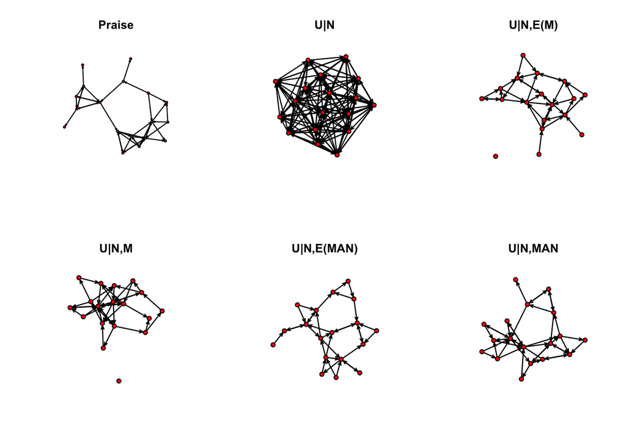

```r
# Begin by drawing a uniform digraph with the same order as the "praise" network
g.un<-rgraph(network.size(sampson[[9]]))

# Now, try a uniform digraph with the same expected number of edges
g.unem<-rgraph(network.size(sampson[[9]]),tp=gden(sampson[[9]]))

# How about a uniform digraph with the same exact number of edges?
g.unm<-rgnm(1,network.size(sampson[[9]]),network.edgecount(sampson[[9]]))

# We can also try the same expected dyad census...
g.uneman<-rguman(1,network.size(sampson[[9]]),mut=dc[9,1],asym=dc[9,2],
    null=dc[9,3])

# ...and, finally, the same exact dyad census
g.unman<-rguman(1,network.size(sampson[[9]]),mut=dc[9,1],asym=dc[9,2],
    null=dc[9,3],method="exact")

# Plot all of the above, along with the original graph
par(mfrow=c(2,3))                                   # Create a 2x3 panel display
plot(sampson[[9]],main="Praise")
gplot(g.un,main="U|N")
gplot(g.unem,main="U|N,E(M)")
gplot(g.unm,main="U|N,M")
gplot(g.uneman,main="U|N,E(MAN)")
gplot(g.unman,main="U|N,MAN")
```

```r
par(mfrow=c(1,1))                                   # Reset the display
```

This is the basis of the permutation tests (CUG tests).

# Conditional Uniform Graph tests

Introduced by Anderson, B.S.; Butts, C.T.; and Carley, K.M. (1999) CUG tests are part of the larger litature in statistics known as Monte Carlo tests. CUG tests can (in a lot of ways) be thought of as the begining point of inferential statistics on networks.

The idea goes like this – we want to know there is some sort of signal in our data! If we can accurately represent the network with a “simple” random graph we know there is no meaningful “structure” in the data (this is analogous to being able to represent a proportion with a mean or showing that your data is well reprented by normal distribution with no covariates).

Here are the four most important baseline models:

- Uniform conditioned on size
- Uniform conditioned on the number of edges
- Uniform conditioned on the dyad census
- Uniform conditioned on all unlabled properties (this is the permutation distribution of a graph)

```r
g<-rguman(1,15,mut=0.25,asym=0.05,null=0.7)

#Test transitivity against size, density, and the dyad census
cug.test(g,gtrans,cmode="size")
```

```
##
## Univariate Conditional Uniform Graph Test
##
## Conditioning Method: size
## Graph Type: digraph
## Diagonal Used: FALSE
## Replications: 1000
##
## Observed Value: 0.3693694
## Pr(X>=Obs): 1
## Pr(X<=Obs): 0
```

```r
cug.test(g,gtrans,cmode="edges")
```

```
##
## Univariate Conditional Uniform Graph Test
##
## Conditioning Method: edges
## Graph Type: digraph
## Diagonal Used: FALSE
## Replications: 1000
##
## Observed Value: 0.3693694
## Pr(X>=Obs): 0.141
## Pr(X<=Obs): 0.86
```

```r
cug.test(g,gtrans,cmode="dyad.census")
```

```
##
## Univariate Conditional Uniform Graph Test
##
## Conditioning Method: dyad.census
## Graph Type: digraph
## Diagonal Used: FALSE
## Replications: 1000
##
## Observed Value: 0.3693694
## Pr(X>=Obs): 0.207
## Pr(X<=Obs): 0.794
```

Now let’s do an emperical case with famous data set on international trade.

```r
## Emperical Case
data(trade)
ctrade<-trade$CRUDE_MATERIALS
cug.test(ctrade,gden)                 # Call cug.test with the gden (density) function
```

```
##
## Univariate Conditional Uniform Graph Test
##
## Conditioning Method: size
## Graph Type: digraph
## Diagonal Used: FALSE
## Replications: 1000
##
## Observed Value: 0.5561594
## Pr(X>=Obs): 0.005
## Pr(X<=Obs): 0.997
```

```r
# Is there more reciprocity than density would suggest?  Let's see.
cug.test(ctrade,grecip,cmode="edges")       # Conditioning on edges, calling grecip
```

```
##
## Univariate Conditional Uniform Graph Test
##
## Conditioning Method: edges
## Graph Type: digraph
## Diagonal Used: FALSE
## Replications: 1000
##
## Observed Value: 0.6992754
## Pr(X>=Obs): 0
## Pr(X<=Obs): 1
```

```r
# Given biases in density and reciprocity, we might look to see if there is a
# bias in transitivity, too.  This time, let's condition on all of the above.
cug.test(ctrade,gtrans,cmode="dyad")   #                Conditioning on dyad census
```

```
##
## Univariate Conditional Uniform Graph Test
##
## Conditioning Method: dyad.census
## Graph Type: digraph
## Diagonal Used: FALSE
## Replications: 1000
##
## Observed Value: 0.733989
## Pr(X>=Obs): 0
## Pr(X<=Obs): 1
```

```r
# We are not limited to simple commands.  Let's try indegree centralization:
ct<-cug.test(ctrade,centralization,cmode="dyad",FUN.arg=list(FUN=degree,
    cmode="indegree"))  # Note that we here must pass not only arguments to
                        # cug.test, but also to centralization and degree!
ct                                                           # Print the result
```

```
##
## Univariate Conditional Uniform Graph Test
##
## Conditioning Method: dyad.census
## Graph Type: digraph
## Diagonal Used: FALSE
## Replications: 1000
##
## Observed Value: 0.4177694
## Pr(X>=Obs): 0
## Pr(X<=Obs): 1
```

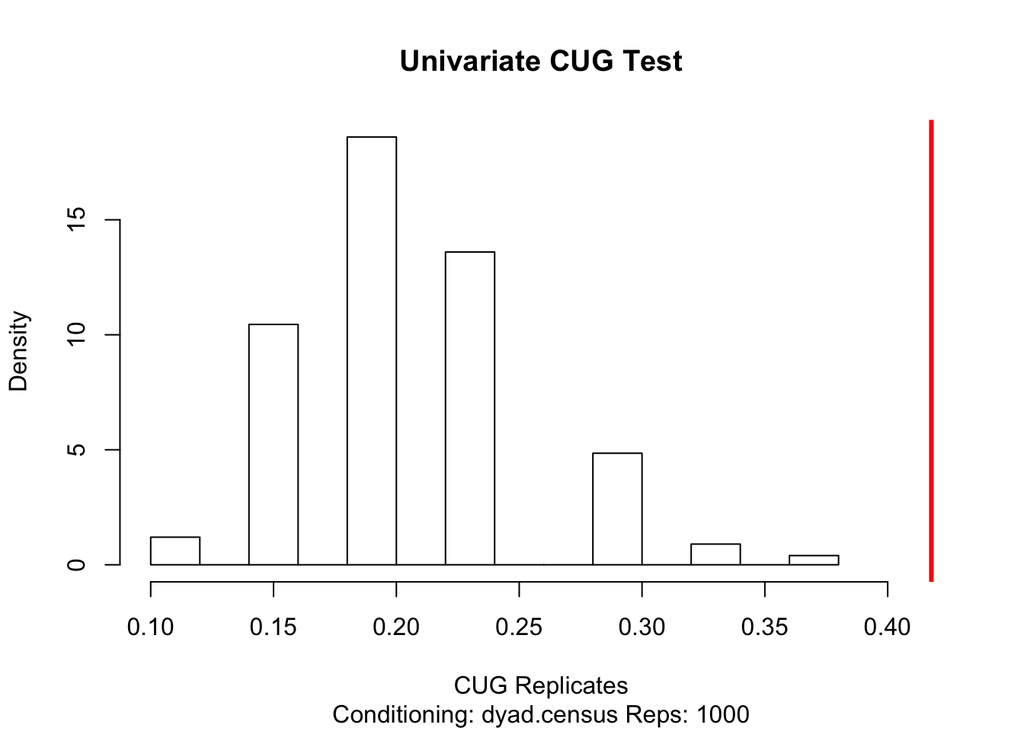

```r
plot(ct)                                                     # Can also plot it!
```

# Bonus code for centrality measures

```r
#######################################
### function that takes a list of network objects and outputs classic
###    centrality scores by nodes and ranks them
#######################################
node.centrality<-function(list.net){
  lapply(list.net,
         function(z){
           x<-symmetrize(as.sociomatrix.sna(z))
           central.nodes<-cbind(degree(x,cmode="indegree"), degree(x,cmode="outdegree"),evcent(x),betweenness(x,rescale=TRUE),
                                closeness(x,cmode="suminvundir"))
           colnames(central.nodes)<-c("idegree","odegree","eigen","betweenness","closeness")
           rownames(central.nodes)<-attr(z,"vnames")

           o1<-order(central.nodes[,1],decreasing =TRUE)
           o2<-order(central.nodes[,2],decreasing =TRUE)
           o3<-order(central.nodes[,3],decreasing =TRUE)
           o4<-order(central.nodes[,4],decreasing =TRUE)
           o5<-order(central.nodes[,5],decreasing =TRUE)
           list(ranking=central.nodes,order=cbind(o1,o2,o3,o4,o5))
         })
}

#########################
### Let's do an example
#########################

### Lin Freeman's famous Beach data
#help(beach)
data(beach)


### Compute Centrality scores
nc<-node.centrality(beach)

### Print
lapply(nc,function(x){head(x[[1]])})
```

```
## $bb
##      idegree odegree      eigen  betweenness closeness
## [1,]      15      15 0.15365255 0.0108088844 0.6785714
## [2,]       7       7 0.06835399 0.0005107654 0.5674603
## [3,]      15      15 0.12967312 0.0177447402 0.6666667
## [4,]       7       7 0.06444699 0.0010659375 0.5674603
## [5,]      26      26 0.22514759 0.0597508077 0.8095238
## [6,]      31      31 0.25595428 0.1324588860 0.8690476
##
## $bc
##      idegree odegree     eigen betweenness closeness
## [1,]      39      39 0.1431214  0.00000000 0.9642857
## [2,]      42      42 0.1534214  0.02631579 1.0000000
## [3,]      42      42 0.1534214  0.02631579 1.0000000
## [4,]      42      42 0.1534214  0.02631579 1.0000000
## [5,]      42      42 0.1534214  0.02631579 1.0000000
## [6,]      42      42 0.1534214  0.02631579 1.0000000
```

```r
### Print ordered by degre
lapply(nc,function(x){head(x[[1]][x$order[,1],])})
```

```
## $bb
##      idegree odegree     eigen betweenness closeness
## [1,]      31      31 0.2559543  0.13245889 0.8690476
## [2,]      28      28 0.2324560  0.09808154 0.8333333
## [3,]      26      26 0.2251476  0.05975081 0.8095238
## [4,]      26      26 0.2257634  0.06533233 0.8095238
## [5,]      25      25 0.2145659  0.05538757 0.7976190
## [6,]      25      25 0.2383233  0.04513281 0.7976190
##
## $bc
##      idegree odegree     eigen betweenness closeness
## [1,]      42      42 0.1534214  0.02631579         1
## [2,]      42      42 0.1534214  0.02631579         1
## [3,]      42      42 0.1534214  0.02631579         1
## [4,]      42      42 0.1534214  0.02631579         1
## [5,]      42      42 0.1534214  0.02631579         1
## [6,]      42      42 0.1534214  0.02631579         1
```